# Challenge 2

```r
# Damit setzen wir das Working Directory auf den Ordner dieser Datei
if (!is.null(parent.frame(2)$ofile)) {
  this.dir <- dirname(parent.frame(2)$ofile)
  setwd(this.dir)}
```

**Get Data**

```r
library(data.table)
machines = fread(file = "machine_data.csv",
                 sep = ',',
                 header = TRUE,
                 stringsAsFactors = FALSE,
                 dec = '.')

products = fread(file = "product_data.csv",
                 sep = ',',
                 header = TRUE,
                 stringsAsFactors = FALSE,
                 dec = '.')

transaction = fread(file = "transactional_data.csv",
                    sep = ',',
                    header = TRUE,
                    stringsAsFactors = FALSE,
                    dec = '.')

mfailures = fread(file = "machine_failures.csv",
                  sep = ',',
                  header = TRUE,
                  stringsAsFactors = FALSE,
                  dec = '.')

mfailures = data.table(mfailures)
transaction = data.table(transaction)
products = data.table(products)
machines = data.table(machines)
```

**1. Merge the transactional dataset with the machine failures data set setting failure variable to 0 when no failure is recorded**

```r
# merge the datasets
transactional = merge(transaction,mfailures, by = c('machine', 'timestamp', 'column'), all.x=T)
setDT(transactional)
# set the failure value of normal records to 0
transactional[is.na(failure),failure:=0]
```

**2. In the transactional data table, create a variable called “last_vend” containing the timestamp of the previous sale of each machine**

```r
#order by machine and date
transactional = transactional[order(machine,date)]

#create "last stand colum" with shift (one down):
transactional[, last_vend := shift(timestamp)]

# Empty first row for each machine since first selling point doesnt have a previous sale:
transaction[, last_vend := c(NA, timestamp[-.N]), by=machine]
summary(transactional)
```

```
    machine      timestamp             column          date           product_name          failure
 Min.   :   1   Length:1840477     Min.   : 0.00   Length:1840477     Length:1840477     Min.   :0.000000
 1st Qu.: 880   Class :character   1st Qu.:13.00   Class :character   Class :character   1st Qu.:0.000000
 Median :1472   Mode  :character   Median :25.00   Mode  :character   Mode  :character   Median :0.000000
 Mean   :1462                      Mean   :27.03                                         Mean   :0.006725
 3rd Qu.:2072                      3rd Qu.:39.00                                         3rd Qu.:0.000000
 Max.   :2724                      Max.   :69.00                                         Max.   :1.000000
  last_vend
 Length:1840477
 Class :character
 Mode  :character
```

**3. Create a new variable in the transactional data table called “deltahours” containing, for every sale, the hours that passed since the last sale**

```r
help("difftime")
transactional[, deltahours := as.numeric(difftime(timestamp,last_vend,units = 'hours'))]
# Only rows without NAs
transactional = transactional[complete.cases(transactional)]
head(transactional)
```

| machine | timestamp | column | date | product_name | failure | last_vend | deltahours |
| --- | --- | --- | --- | --- | --- | --- | --- |
| 1 | 2017-01-02 12:32:20 | 54 | 2017-01-02 | flavoured_carbonates_2 | 0 | 2017-01-02 12:20:19 | 0.20027778 |
| 1 | 2017-01-02 13:11:15 | 21 | 2017-01-02 | sugar_confectionary_incl_gums_3 | 0 | 2017-01-02 12:32:20 | 0.64861111 |
| 1 | 2017-01-02 13:13:19 | 24 | 2017-01-02 | sugar_confectionary_incl_gums_1 | 0 | 2017-01-02 13:11:15 | 0.03444444 |
| 1 | 2017-01-02 13:42:20 | 50 | 2017-01-02 | unflavoured_carbonates_1 | 0 | 2017-01-02 13:13:19 | 0.48361111 |
| 1 | 2017-01-02 13:56:16 | 24 | 2017-01-02 | sugar_confectionary_incl_gums_1 | 0 | 2017-01-02 13:42:20 | 0.23222222 |
| 1 | 2017-01-02 14:02:05 | 33 | 2017-01-02 | chocolate_based_3 | 0 | 2017-01-02 13:56:16 | 0.09694444 |

**4. Create an auxiliary data table called “machine_daily_average” 2ith the average daily sales per machine. Use this auxiliary table to attach to every row of the transactional data table to the average daily sales per machine.**

```r
machine_daily_average = transactional[, .(daily_sales_machine=length(product_name)/uniqueN(date)),by=machine]
transactional = merge(transactional,machine_daily_average, by = 'machine', all.x=T)
head(transactional)
```

| machine | timestamp | column | date | product_name | failure | last_vend | deltahours | daily_sales_machine |
| --- | --- | --- | --- | --- | --- | --- | --- | --- |
| 1 | 2017-01-02 12:32:20 | 54 | 2017-01-02 | flavoured_carbonates_2 | 0 | 2017-01-02 12:20:19 | 0.20027778 | 8.681818 |
| 1 | 2017-01-02 13:11:15 | 21 | 2017-01-02 | sugar_confectionary_incl_gums_3 | 0 | 2017-01-02 12:32:20 | 0.64861111 | 8.681818 |
| 1 | 2017-01-02 13:13:19 | 24 | 2017-01-02 | sugar_confectionary_incl_gums_1 | 0 | 2017-01-02 13:11:15 | 0.03444444 | 8.681818 |
| 1 | 2017-01-02 13:42:20 | 50 | 2017-01-02 | unflavoured_carbonates_1 | 0 | 2017-01-02 13:13:19 | 0.48361111 | 8.681818 |
| 1 | 2017-01-02 13:56:16 | 24 | 2017-01-02 | sugar_confectionary_incl_gums_1 | 0 | 2017-01-02 13:42:20 | 0.23222222 | 8.681818 |
| 1 | 2017-01-02 14:02:05 | 33 | 2017-01-02 | chocolate_based_3 | 0 | 2017-01-02 13:56:16 | 0.09694444 | 8.681818 |

**5. Create a new variable called “delta” in the transactional data table containing a normalized version of deltahours consisting on the deltahours associated with each sale divided by the average deltahours of each machine i.e. delta = deltahours /(24/daily_sales_machine). The interpretation of delta is the amount of “missed sales” if the machine was selling at a constant rate**

```r
transactional$delta <- transactional[, .(delta=as.numeric(deltahours*daily_sales_machine/24, units='hours'))]
head(transactional)
```

| machine | timestamp | column | date | product_name | failure | last_vend | deltahours | daily_sales_machine | delta |
| --- | --- | --- | --- | --- | --- | --- | --- | --- | --- |
| 1 | 2017-01-02 12:32:20 | 54 | 2017-01-02 | flavoured_carbonates_2 | 0 | 2017-01-02 12:20:19 | 0.20027778 | 8.681818 | 0.07244897 |
| 1 | 2017-01-02 13:11:15 | 21 | 2017-01-02 | sugar_confectionary_incl_gums_3 | 0 | 2017-01-02 12:32:20 | 0.64861111 | 8.681818 | 0.23463016 |
| 1 | 2017-01-02 13:13:19 | 24 | 2017-01-02 | sugar_confectionary_incl_gums_1 | 0 | 2017-01-02 13:11:15 | 0.03444444 | 8.681818 | 0.01246002 |
| 1 | 2017-01-02 13:42:20 | 50 | 2017-01-02 | unflavoured_carbonates_1 | 0 | 2017-01-02 13:13:19 | 0.48361111 | 8.681818 | 0.17494266 |
| 1 | 2017-01-02 13:56:16 | 24 | 2017-01-02 | sugar_confectionary_incl_gums_1 | 0 | 2017-01-02 13:42:20 | 0.23222222 | 8.681818 | 0.08400463 |
| 1 | 2017-01-02 14:02:05 | 33 | 2017-01-02 | chocolate_based_3 | 0 | 2017-01-02 13:56:16 | 0.09694444 | 8.681818 | 0.03506892 |

```r
# Checking if high deltahours have a strong correlation with failure:
high_deltas = mean(transactional$failure[transactional$deltahours >
                                           unname(quantile(transactional$deltahours,0.99,na.rm = TRUE))],na.rm = TRUE)

low_deltas = mean(transactional$failure[transactional$deltahours <
                                          unname(quantile(transactional$deltahours,0.99, na.rm = TRUE))], na.rm = TRUE)

influence_deltas = data.table(high_deltas,low_deltas)
influence_deltas
```

| high_deltas | low_deltas |
| --- | --- |
| 0.2019126 | 0.004753934 |

**6. Select 30% of the machines in the transactional data for testing and 70% of the machines for training and train a linear logistic regression model called “m” to predict whether a machine has a failure as a function of variable delta. What is the value of the intercept and the coefficient accompanying variable delta?**

```r
set.seed(42)
idx <- sample(x=unique(transactional$machine), size=round(0.7*length(unique(transactional$machine)), 0))

train <- transactional[machine %in% idx, ]
test <- transactional[!machine %in% idx, ]

m <- glm(failure ~ delta, train, family="binomial")
```

```
glm.fit: Angepasste Wahrscheinlichkeiten mit numerischem Wert 0 oder 1 aufgetreten
```

```r
summary(m)
```

```
Call:
glm(formula = failure ~ delta, family = "binomial", data = train)

Deviance Residuals:
    Min       1Q   Median       3Q      Max
-3.0331  -0.0616  -0.0482  -0.0447   3.7182

Coefficients:
             Estimate Std. Error z value Pr(>|z|)
(Intercept) -6.911617   0.023127  -298.9   <2e-16 ***
delta        0.562050   0.003131   179.5   <2e-16 ***
---
Signif. codes:  0 ‘***’ 0.001 ‘**’ 0.01 ‘*’ 0.05 ‘.’ 0.1 ‘ ’ 1

(Dispersion parameter for binomial family taken to be 1)

    Null deviance: 103681  on 1281524  degrees of freedom
Residual deviance:  58250  on 1281523  degrees of freedom
AIC: 58254

Number of Fisher Scoring iterations: 9
```

**Answer:** Intercept : -6.911617; coef,delta: 0.562049

**a) What’s the AUC, a measure of quality, of the model you have built on the train set? and on test set?**

```r
library(pROC)
pred_train = predict(m, newdata = train, type = "response")
pred_test = predict(m, newdata = test, type = "response")

auc(train$failure, pred_train)
```

```
Area under the curve: 0.9198
```

```r
auc(test$failure, pred_test)
```

```
Area under the curve: 0.9206
```

**b) Plot the function of probability of failure with respect to delta to gain intuition:**

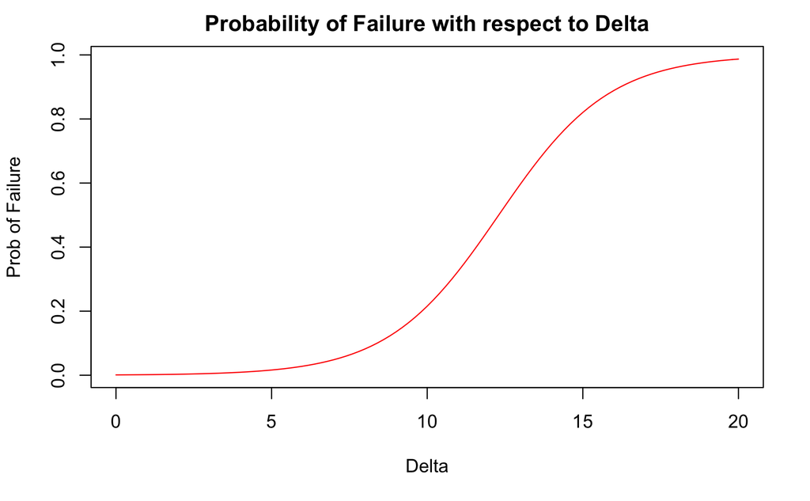

```r
intercept = m$coefficients["(Intercept)"]
coefficient = m$coefficients["delta"]
f = function(x){(1/(1+exp(-(intercept + (coefficient*x)))))}
curve(f, 0, 20,
      xlab = "Delta", ylab="Prob of Failure", col="red",
      main = "Probability of Failure with respect to Delta")
```

**c) Let us create alarms with two levels of priority: med-risk and high-risk. Med-risk alarms will fire when the probability of failure is >=60% and High-risk when that probability is >=80%.**

**i. What are the threshold deltas for each type of alarm to fire? #Hint (check the case)**

```r
# Can be solved using the function and log it:
log_f = function(x){
  (log((1/x)-1) + intercept) / -coefficient}

threshold_med_risk = log_f(0.6)
threshold_high_risk = log_f(0.8)

threshold_med_risk
```

```
(Intercept)
   13.01857
```

```r
threshold_high_risk
```

```
(Intercept)
   14.76367
```

**ii. How many of these alarms would be fired per day on average according to your model?**

```r
daily_alarm_med_risk = length(transactional$delta[transactional$delta >= threshold_med_risk]) / length(unique(transactional$date))

daily_alarm_high_risk = length(transactional$delta[transactional$delta >= threshold_high_risk]) / length(unique(transactional$date))

daily_alarm_med_risk
```

```
[1] 41.17778
```

```r
daily_alarm_high_risk
```

```
[1] 27.7
```

**iii. What % of these will be “false alarms” i.e. failure variable is equal to 0, for each level of priority?**

```r
transactional$alarm_med_risk = 0
transactional$alarm_med_risk[transactional$delta >= threshold_med_risk] = 1

transactional$alarm_high_risk = 0
transactional$alarm_high_risk[transactional$delta >= threshold_high_risk] = 1

false_alarm_rate_med_risk = sum(transactional$alarm_med_risk[transactional$failure == 0]) / sum(transactional$alarm_med_risk)
false_alarm_rate_high_risk = sum(transactional$alarm_high_risk[transactional$failure == 0]) / sum(transactional$alarm_high_risk)


sprintf("%1.2f%%", 100*false_alarm_rate_med_risk)
```

```
[1] "20.24%"
```

```r
sprintf("%1.2f%%", 100*false_alarm_rate_high_risk)
```

```
[1] "8.90%"
```

**d) In this exercise we will estimate the profit impact of our EWS system vs the current system:**  
**i. If we set the EWS only with the med-risk alarms, what is the annual profit we will generate vs the current system as a % of the total profit?**

**ii. And if we set the EWS only with the high-risk alarms?**

```r
# Assumptions:
margin_per_item = 1.7
cost_of_checking = 10
time_to_fix = 1.5
current_false_alarms = 2.2
```

Function for calculating increase in profit based on risk threshold:

```r
profit_increase = function(threshold) {
  if (threshold == threshold_med_risk){
    dt_alarms = transactional[transactional$alarm_med_risk == 1,]
  }
  else {
    dt_alarms = transactional[transactional$alarm_high_risk == 1,]
  }

## Additional costs from false alarms
  # New costs
  new_costs = nrow(dt_alarms[dt_alarms$failure == 0]) * cost_of_checking

  # Current costs
  current_costs = transactional[, .(max = max(timestamp), min = min(timestamp)), by = machine]
  current_costs$cost = as.numeric(difftime(current_costs$max,
                                           current_costs$min,
                                           units = "days"))/ 365 * current_false_alarms * cost_of_checking
  # Total current costs
  current_costs = sum(current_costs$cost)

  # Net costs
  net_costs = new_costs - current_costs
#----------------------

# Additional revenue
  dt_alarms[, threshold_hours := threshold * (24 / daily_sales_machine)]
  dt_alarms[, threshold_hours_fixed := threshold_hours + time_to_fix]
  dt_alarms[, delta_fixed := threshold_hours_fixed * daily_sales_machine / 24 ]

# Additional sales:
  dt_alarms[, won_sales := failure * (delta - delta_fixed)]
  add_margin = sum(dt_alarms$won_sales) * margin_per_item

# Profit increase
  delta_profit = add_margin - net_costs
  current_profit = nrow(transactional) * margin_per_item
  profit_increase = delta_profit/current_profit

  return(profit_increase)
}
```

```r
# i) increase Profit of medium risk:
profit_increase_medium_risk = profit_increase(threshold_med_risk)
sprintf("%1.2f%%", 100*profit_increase_medium_risk)
```

```
[1] "2.39%"
```

```r
# ii) Increase Profit of high risk
profit_increase_high_risk = profit_increase(threshold_high_risk)
sprintf("%1.2f%%", 100*profit_increase_high_risk)
```

```
[1] "2.35%"
```